# Basic Bash

David Gerard

2022-11-16

# Learning Objectives

- Open up the terminal.
- Basic shell commands.
- Chapter 4 of [Git for Scientists](https://milesmcbain.github.io/git_4_sci/).
- [Terminus](http://web.mit.edu/mprat/Public/web/Terminus/Web/main.html).

# The Command Line

- The **command line** is like the R command prompt: you insert code, hit enter, and then the computer executes your command.
- However, instead of inserting R code, you insert [Shell Script](https://en.wikipedia.org/wiki/Shell_script).
- In this class, we will use the command line primarily for two things:
  - Moving around your file system.
  - Running git commands.
- Other words for command line: shell, terminal, command line interface (cli), and console.
  - These terms are technically slightly [different](https://askubuntu.com/questions/506510/what-is-the-difference-between-terminal-console-shell-and-command-line).
- There are many types of shells, each with their own scripting language. We will use the bash scripting language for this class.
- A huge difference between R and bash is how commands/functions are called.
  - R: `f(x, y = 1)`
  - Bash: `f x --y=1`
  - Arguments that are “flags” use only one dash, like `f x -g` would incorporate the `g` flag.
- If you are using Linux or Mac, then you can keep going. If you are using Windows, you need to first download and install git (and thus git bash) from here: http://git-scm.com/download/win. You might need to restart R Studio if you are already running it.
- Open up the terminal
  - Windows: Open up the `Git Bash` app. It should look like this:

[figure not shown]

  - Mac: On your Mac, do one of the following:
    - Click the Launchpad icon in the Dock, type Terminal in the search field, then click Terminal.
    - In the Finder , open the /Applications/Utilities folder, then double-click Terminal.
  - Ubuntu: Do one of the following
    - Open the dash and search for “terminal”. Open up the terminal.
    - Use keyboard shortcut: Ctrl+Alt+T
    - It should look like this:

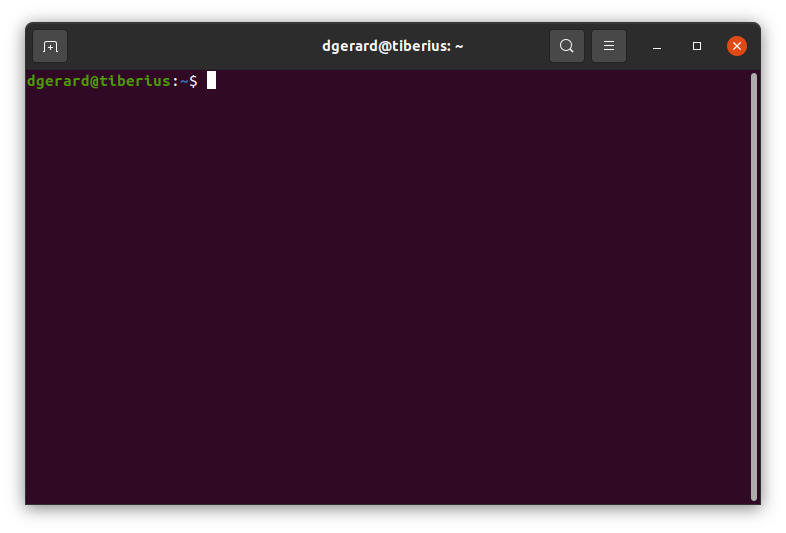

- All commands get placed after the dollar sign.
- The path before the dollar sign is the working directory of the terminal, **not** R’s working directory. It’s where the shell will reference all files from.
- The tilde “`~`” is shorthand for the “home directory”. Each computer has a home directory that is the “default directory”.

# Useful Commands:

- `pwd`: Print working directory. Show the current working directory. This is like `getwd()` in R.

  ```bash
  pwd
  ```

  ```
  /home/dgerard/Dropbox/teaching/stat_413_613/lectures/01_git
  ```

- `ls`: List the current files and folders in a directory.

  ```bash
  ls
  ```

  ```
  01_basic_bash.Rmd
  01_figs
  01_git_branch.Rmd
  01_git_github.Rmd
  01_git_lfs.Rmd
  01_git_setup.Rmd
  blischak_etal_2016.PDF
  citation.bib
  graphics
  ```

- `cd`: Change directories. This is like `setwd()` in R. As when we specified paths in R, using two periods mean “move back a folder”.

  ```bash
  cd ../
  pwd
  ```

  ```
  /home/dgerard/Dropbox/teaching/stat_413_613/lectures
  ```

  - If you use `cd` without specifying a folder to move to, it will move the working directory to the home directory.

  ```bash
  cd
  pwd
  ```

  ```
  /home/dgerard
  ```

  - OK, I’m going to move us back to the 01_git directory.

- `man`: Read the manual of a command. Just like `help()` in R.

  ```bash
  man ls
  ```

  - This will open up the man page of `ls`. You can scroll through this page using the up and down arrows. You can exit this page by typing `q`.
  - This won’t work for Git Bash (for Windows users). Instead, you’ll need to type

    ```bash
    ls --help
    ```

- **Exercise**: What is your home directory? What files/folders exist in your home directory? Navigate to it and then navigate back to your notes.
- **Exercise**: Where does the following command take you? How does it work?

  ```bash
  cd ~/../../..
  ```

- **Exercise**: Read the manual page of `ls`. What does the `a` flag do? Try it out!

# Other commands.

- `touch`: Create an empty file.

  ```bash
  touch empty_file.txt
  ```

- `more`: Open up a preview of a document. You can exit the preview by typeing `q`.

  ```bash
  more 01_basic_bash.Rmd
  ```

- `cp`: Copy a file.

  ```bash
  cp 01_basic_bash.Rmd hellobash.Rmd
  ls
  ```

  ```
  01_basic_bash.Rmd
  01_figs
  01_git_branch.Rmd
  01_git_github.Rmd
  01_git_lfs.Rmd
  01_git_setup.Rmd
  blischak_etal_2016.PDF
  citation.bib
  graphics
  hellobash.Rmd
  ```

- `mv`: Move/rename a file.

  ```bash
  mv hellobash.Rmd goodbyebash.Rmd
  ls
  ```

  ```
  01_basic_bash.Rmd
  01_figs
  01_git_branch.Rmd
  01_git_github.Rmd
  01_git_lfs.Rmd
  01_git_setup.Rmd
  blischak_etal_2016.PDF
  citation.bib
  goodbyebash.Rmd
  graphics
  ```

- `rm`: Remove a file.

  ```bash
  rm goodbyebash.Rmd
  ls
  ```

  ```
  01_basic_bash.Rmd
  01_figs
  01_git_branch.Rmd
  01_git_github.Rmd
  01_git_lfs.Rmd
  01_git_setup.Rmd
  blischak_etal_2016.PDF
  citation.bib
  graphics
  ```

- `mkdir`: Make a directory/folder.

  ```bash
  mkdir tempdir
  ls
  ```

  ```
  01_basic_bash.Rmd
  01_figs
  01_git_branch.Rmd
  01_git_github.Rmd
  01_git_lfs.Rmd
  01_git_setup.Rmd
  blischak_etal_2016.PDF
  citation.bib
  graphics
  tempdir
  ```

- `rmdir`: Remove a directory/folder.

  ```bash
  rmdir tempdir
  ls
  ```

  ```
  01_basic_bash.Rmd
  01_figs
  01_git_branch.Rmd
  01_git_github.Rmd
  01_git_lfs.Rmd
  01_git_setup.Rmd
  blischak_etal_2016.PDF
  citation.bib
  graphics
  ```

# String search with `grep`

Find any string in any file in the current working directory (or subdirectories or the current working directory).

- `-r` recursive
- `-n` line number
- `-w` whole word only
- `-e` pattern
- `pdfgrep` (need to install separately) for searching text in PDFs.

```bash
grep -rnw -e "move"
```

```
01_basic_bash.Rmd:93:  paths in R, using two periods mean "move back a folder".
01_basic_bash.Rmd:100:    - If you use `cd` without specifying a folder to move to, it will move the
01_basic_bash.Rmd:108:    - OK, I'm going to move us back to the 01_git directory.
01_basic_bash.Rmd:200:grep -rnw -e "move"
01_git_github.Rmd:69:- You can go back to previous versions of your code/text, then move forward to
01_git_github.Rmd:226:- Then move into your new repo
.Rhistory:2:grep -rnwe "move"
```

```bash
grep -rnw -e "mov"
```

```
01_basic_bash.Rmd:204:grep -rnw -e "mov"
01_basic_bash.Rmd:208:grep -rn -e "mov"
```

```bash
grep -rn -e "mov"
```

```
01_basic_bash.Rmd:93:  paths in R, using two periods mean "move back a folder".
01_basic_bash.Rmd:100:    - If you use `cd` without specifying a folder to move to, it will move the
01_basic_bash.Rmd:108:    - OK, I'm going to move us back to the 01_git directory.
01_basic_bash.Rmd:168:- `rm`: Remove a file.
01_basic_bash.Rmd:182:- `rmdir`: Remove a directory/folder.
01_basic_bash.Rmd:200:grep -rnw -e "move"
01_basic_bash.Rmd:204:grep -rnw -e "mov"
01_basic_bash.Rmd:208:grep -rn -e "mov"
01_basic_bash.Rmd:233:I'll remove that file now
01_git_github.Rmd:69:- You can go back to previous versions of your code/text, then move forward to
01_git_github.Rmd:226:- Then move into your new repo
01_git_github.Rmd:398:- Lines after a "`+`" are being added. Lines after a "`-`" are being removed.
.Rhistory:2:grep -rnwe "move"
.Rhistory:9:conda_remove(envname = "r-reticulate")
.Rhistory:11:conda_remove("bs4")
```

# Download data with `wget`

Non-interactive downloading of data.

Not available for Git Bash for Windows.

- `-nc` Don’t download new copies if already there.
- `-nd` Put all files in current working directory.
- `-P` Tell where to download the files. Default is current working directory (`.`)
- `-r` Recursive downloading. Download all files in the directory up to a certain level.
- `l` Determine the level for recursive downloading.

E.g. to download the HTML file that contains the Wikipedia list of [theological demons](https://en.wikipedia.org/wiki/List_of_theological_demons), we can go

```bash
wget -nc -nd https://en.wikipedia.org/wiki/List_of_theological_demons
```

```
--2022-11-16 13:29:02--  https://en.wikipedia.org/wiki/List_of_theological_demons
Resolving en.wikipedia.org (en.wikipedia.org)... 208.80.154.224, 2620:0:861:ed1a::1
Connecting to en.wikipedia.org (en.wikipedia.org)|208.80.154.224|:443... connected.
HTTP request sent, awaiting response... 200 OK
Length: 79328 (77K) [text/html]
Saving to: ‘List_of_theological_demons’

     0K .......... .......... .......... .......... .......... 64% 15.2M 0s
    50K .......... .......... .......                         100% 22.6M=0.004s

2022-11-16 13:29:02 (17.2 MB/s) - ‘List_of_theological_demons’ saved [79328/79328]
```

```bash
ls
```

```
01_basic_bash.Rmd
01_figs
01_git_branch.Rmd
01_git_github.Rmd
01_git_lfs.Rmd
01_git_setup.Rmd
blischak_etal_2016.PDF
citation.bib
graphics
List_of_theological_demons
```

I’ll remove that file now

```bash
rm List_of_theological_demons
```

# Search your command history with `reverse-i-search`

1. `ctrl`+`r` to get search prompt
2. Type a search term
3. `ctrl`+`r` to cycle through matches
4. Hit `enter` if you want to reuse the match. Hit `ctrl`+`c` to exit out of the search.